# Introducción a la Mecánica Orbital

[figure not shown]

### Brandon Escamilla, Edson Perez, Salvador Huante 2019-02-14

# Índice

## I. Teoría

1. ¿Por qué caen los objetos?
2. La Tierra y el Sistema Solar
3. ¿Qué es una órbita?
4. Asteroides y cometas
5. Satélites artificiales
6. Bibliografía

## II. Práctica

## III. Conclusiones y preguntas

# I. Teoría

## 1. ¿Por qué caen los objetos?

[figure not shown]

### Ley de gravitación universal

- Por el hecho de tener **masa**, los objetos atraen a otros
- La fuerza ejercida entre dos cuerpos es igual al producto de sus masas e inversamente proporcional al cuadrado de la distancia que los separa:

[figure not shown]

### Segunda ley de Newton o ley fundamental de la dinámica

$$ \vec{F} = m \vec{a} $$

Entonces... ¿cómo se acelera un objeto sometido a la fuera de la gravedad que ejerce otro?

$$ \vec{a} = \vec{F} \frac{1}{m} = G \frac{m M}{r^2} \frac{1}{m} \vec{u} = \frac{G M}{r^2} \vec{u} = \frac{\mu}{r^2} \vec{u} $$

¡Sí! La aceleración de un objeto bajo la gravedad de otro *no depende de la masa del objeto*, solo de la del atractor.

### ¿Orbitar o caer?

- Imaginemos este experimento: lanzamos una bala de cañón cada vez más fuerte
- Al principio caerá al pie de la montaña, y cada vez más lejos...
- ...hasta que el suelo se empiece a hundir bajo la trayectoria...
- ...¡y al final nunca lo toque!
- **Estar en órbita es estar cayendo permanentemente**

[figure not shown]

### Teoria de Kepler

A través de un estudio de por vida de los movimientos de los cuerpos en el sistema solar, Johannes Kepler (1571-1630) pudo derivar tres leyes básicas conocidas como leyes de Kepler del movimiento planetario. Utilizando los datos compilados por su mentor Tycho Brahe (1546-1601), Kepler encontró las siguientes regularidades después de años de cálculos laboriosos:

1. Todos los planetas se mueven en órbitas elípticas con el sol en un foco.
2. Una línea que une cualquier planeta al sol arrastra áreas iguales en tiempos iguales.
3. El cuadrado del período de cualquier planeta alrededor del sol es proporcional al cubo de la distancia media del planeta al sol.

[figure not shown]

## 2. La Tierra y el Sistema Solar

[figure not shown]

## 3. ¿Qué es una órbita?

- Una órbita es una trayectoria alrededor de un cuerpo celeste, incluyendo la Tierra
- Usando un modelo simplificado, solo pueden ser elipses (caso especial: círculos) o hipérbolas (caso especial: parábolas)
- Se describen usando **parámetros geométricos** y, en ocasiones, cinemáticos
- El plano de la órbita se corta con un plano de referencia formando la **línea de nodos**

[figure not shown]

### Elementos keplerianos

Forma de la órbita:

- $a$ **Semieje mayor**: para elipses, mitad de la distancia del un extremo a otro
- $e$ **Excentricidad**: medida de achatamiento (0 para círculos, menor que 1 para elipses, mayor que 1 para hipérbolas)

Posición del plano de la órbita:

- $i$ **Inclinación**: con respecto al plano de referencia
- $\Omega$ **Ascensión recta del nodo ascendente**: ángulo (ascensión recta) entre la dirección de referencia y el punto (nodo) en el que el satélite cruza el plano "subiendo" (ascendente)
- $\omega$ **Argumento del pericentro**: ángulo (argumento) entre la línea de nodos y el punto más cercano al atractor (pericentro)

Posición del objeto dentro de la órbita:

- $\nu$ **Anomalía verdadera**: ángulo (anomalía) entre el pericentro y la posición actual

[figure not shown]

### Tipos de órbitas

**Intro**: Para que una nave espacial alcance la órbita de la Tierra, debe ser lanzada a una elevación sobre la atmósfera de la Tierra y acelerada a la velocidad orbital. La órbita de mayor eficiencia energética, que requiere la menor cantidad de propelente, es una órbita de baja inclinación. Para lograr tal órbita, se lanza una nave espacial en dirección este desde un sitio cerca del **ecuador de la Tierra**.

**La ventaja es que la velocidad de rotación de la Tierra contribuye a la velocidad orbital final de la nave.**

**Las órbitas geosincrónicas (GEO)** son órbitas circulares alrededor de la Tierra que tienen un período de 24 horas. Una órbita geosíncrona con una inclinación de cero grados se denomina órbita **geoestacionaria**. Una nave espacial en una órbita geoestacionaria se mantendra inmóvil por encima de una posición en el ecuador de la Tierra. Por esta razón, son ideales para algunos tipos de satélites de comunicación y meteorológicos. Para alcanzar la órbita geosincrónica, una nave espacial se lanza primero a una órbita elíptica con un apogeo de **35,786 km (22,236 millas)** llamada órbita de transferencia geosincrónica (GTO). Luego, la órbita se circulariza disparando el motor de la nave espacial al apogeo. **Poliastro o KSP**

**Las órbitas polares (PO)** son órbitas con una inclinación de 90 grados. Las órbitas polares son útiles para satélites que realizan operaciones de mapeo y / o vigilancia porque a medida que el planeta gira, la nave tiene acceso a prácticamente todos los puntos de la superficie del planeta.

**Órbitas en movimiento:** un satélite en órbita está sujeto a una gran cantidad de influencias gravitacionales. Primero, los planetas no son perfectamente esféricos y tienen una distribución de masa ligeramente desigual. Estas fluctuaciones tienen un efecto en la trayectoria de una nave espacial. Además, el sol, la luna y los planetas contribuyen con una influencia gravitatoria en un satélite en órbita. Con una planificación adecuada, es posible diseñar una órbita que aproveche estas influencias para inducir una **precesión** en el plano orbital del satélite. La órbita resultante se llama órbita andante, o órbita de precesión.

**Las órbitas síncronas solares (SSO)** son órbitas en movimiento cuyo plano orbital precede al mismo período que el período de órbita solar del planeta. En tal órbita, un satélite cruza la periapsis aproximadamente a la misma hora local en cada órbita. Esto es útil si un satélite transporta instrumentos que dependen de un cierto ángulo de iluminación solar en la superficie del planeta. Para mantener una sincronización síncrona exacta, puede ser necesario realizar maniobras de propulsión ocasionales para ajustar la órbita.

**Las órbitas de Molniya** son órbitas terrestres muy **excéntricas** con períodos de aproximadamente 12 horas. La inclinación orbital se elige de modo que la tasa de cambio del perigeo sea cero, por lo que tanto el apogeo como el perigeo se pueden mantener en latitudes fijas. Esta condición ocurre en inclinaciones de **63.4 grados** y **116.6 grados**. Para estas órbitas, el argumento del perigeo se coloca típicamente en el hemisferio sur, por lo que el satélite permanece sobre el hemisferio norte cerca del apogeo durante aproximadamente 11 horas por órbita. Esta orientación puede proporcionar una buena cobertura del suelo en latitudes altas del norte. **Motivo de 63.4 grados:** https://people.sc.fsu.edu/~lb13f/projects/space_environment/egm96.php

**Las órbitas de transferencia de Hohmann**: son trayectorias interplanetarias cuya ventaja es que consumen la menor cantidad posible de combustible. Una órbita de transferencia de Hohmann a un planeta exterior, como Marte, se logra lanzando una nave espacial y acelerándola en la dirección de la revolución de la Tierra alrededor del sol hasta que se libera de la gravedad de la Tierra y alcanza una velocidad que lo coloca en una órbita solar.

[figure not shown]

### Órbitas reales

- Las órbitas **reales** se desvían respecto al modelo simplificado debido a **perturbaciones**
- Entre ellas: resto de cuerpos del Sistema Solar, no uniformidad del atractor, presión de radiación, atmósfera (cuando la hay)...
- Es **muy costoso** tener todos estos factores en cuenta y hacer una predicción precisa y exacta
- Se toman medidas **redundantes** (ópticas, láser, GPS) y se refinan continuamente
- Predicciones de la NASA: https://ssd.jpl.nasa.gov/horizons.cgi
- Paper sobre como afecta el magnetismo de la tierra: https://people.sc.fsu.edu/~lb13f/projects/space_environment/egm96.php

## 4. Asteroides y cometas

- Nos centraremos en los **cuerpos cercanos a la Tierra**, comúnmente conocidos como NEOs (de *Near Earth Objects*)
- Son cometas y asteroides a los que las fuerzas gravitatorias del Sistema Solar han atraído a las cercanías de la Tierra
- ¡Se conocen más 16000!
- Fuentes de datos:
  - JPL Small-Body Database Browser https://ssd.jpl.nasa.gov/sbdb.cgi
  - HORIZONS https://ssd.jpl.nasa.gov/horizons.cgi
  - Minor Planet Center https://www.minorplanetcenter.net/data
  - NEODyS http://newton.dm.unipi.it/neodys/
  - Video rosetta: https://www.youtube.com/watch?v=iEQuE5N3rwQ

[figure not shown]

## 5. Satélites artificiales

- Actualmente **~2200** satélites en órbita ([fuente](https://www.wolframalpha.com/input/?i=current+number+of+satellites+in+orbit))
- Diversos tipos: observación de la Tierra, científicos, comunicaciones, militares...

[figure not shown]

## 6. Bibliografía

- "Orbital Mechanics for Engineering Students", de Curtis
- Curso online del MIT por Richard Battin https://ocw.mit.edu/courses/aeronautics-and-astronautics/16-346-astrodynamics-fall-2008/
- "Basic of Orbital Mechanics": http://www.braeunig.us/space/orbmech.htm

# II. Práctica Por si quieren!

```python
import numpy as np
import matplotlib.pyplot as plt
plt.ion()  # To immediately show plots

from astropy import units as u

from poliastro.bodies import Earth, Mars, Sun
from poliastro.twobody import Orbit

plt.style.use("seaborn")  # Recommended
```

```python
# Data from Curtis, example 4.3
r = [-6045, -3490, 2500] * u.km
v = [-3.457, 6.618, 2.533] * u.km / u.s

ss = Orbit.from_vectors(Earth, r, v)
```

```python
ss
```

```
7283 x 10293 km x 153.2 deg (GCRS) orbit around Earth (♁) at epoch J2000.000 (TT)
```

```python
ss.epoch
```

```
<Time object: scale='tt' format='jyear_str' value=J2000.000>
```

```python
ss.epoch.iso
```

```
'2000-01-01 12:00:00.000'
```

```python
ss.frame
```

```
<GCRS Frame (obstime=J2000.000, obsgeoloc=(0., 0., 0.) m, obsgeovel=(0., 0., 0.) m / s)>
```

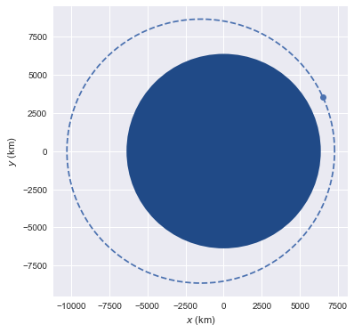

```python
from poliastro.plotting import plot
plot(ss)
```

### Definiendo la órbita: objetos `Orbit`

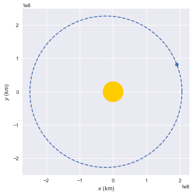

```python
# Data for Mars at J2000 from JPL HORIZONS
a = 1.523679 * u.AU
ecc = 0.093315 * u.one
inc = 1.85 * u.deg
raan = 49.562 * u.deg
argp = 286.537 * u.deg
nu = 23.33 * u.deg

marteOrbit = Orbit.from_classical(Sun, a, ecc, inc, raan, argp, nu)
plot(marteOrbit)
```

### Avanzando en el tiempo: propagación

```python
from poliastro.examples import iss
iss
```

```
6772 x 6790 km x 51.6 deg (GCRS) orbit around Earth (♁) at epoch 2013-03-18 12:00:00.000 (UTC)
```

```python
iss.epoch
```

```
<Time object: scale='utc' format='iso' value=2013-03-18 12:00:00.000>
```

```python
iss.nu.to(u.deg)
```

$46.595805 \; \mathrm{{}^{\circ}}$

```python
iss.n.to(u.deg / u.min)
```

$3.8870106 \; \mathrm{\frac{{}^{\circ}}{min}}$

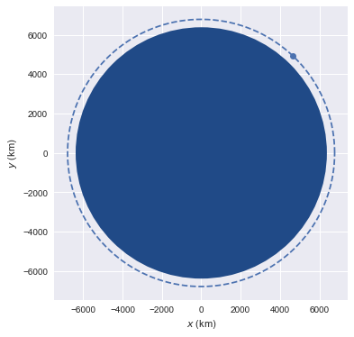

```python
plot(iss)
```

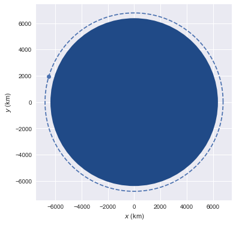

```python
iss_30m = iss.propagate(30 * u.min)
iss_30m.epoch  # Notice we advanced the epoch!
iss_30m.nu.to(u.deg)
plot(iss_30m)
```

### Cambiando la órbita: objetos `Maneuver`

```python
from poliastro.maneuver import Maneuver

dv = [5, 0, 0] * u.m / u.s

man = Maneuver.impulse(dv)
man = Maneuver((0 * u.s, dv))  # Equivalent

ss_i = Orbit.circular(Earth, alt=700 * u.km)

hoh = Maneuver.hohmann(ss_i, 36000 * u.km)


print("Total cost:" , hoh.get_total_cost())

print("Total time: ", hoh.get_total_time())

      #Aplicando Maniobra
ss_f = ss_i.apply_maneuver(hoh)
```

```
Total cost: 3.617399903465751 km / s
Total time:  15729.733147123983 s
```

```python
ss_f
```

```
36000 x 36000 km x 0.0 deg (GCRS) orbit around Earth (♁) at epoch J2000.000 (TT)
```

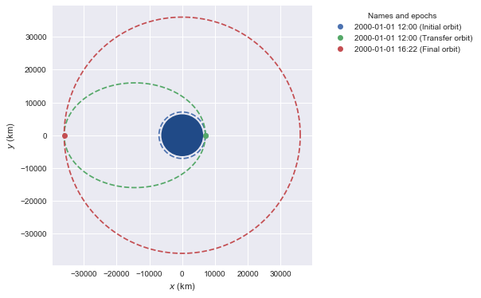

```python
from poliastro.plotting import OrbitPlotter

op = OrbitPlotter()
ss_a, ss_f = ss_i.apply_maneuver(hoh, intermediate=True)
op.plot(ss_i, label="Initial orbit")
op.plot(ss_a, label="Transfer orbit")
op.plot(ss_f, label="Final orbit")
```

### Space X Roadster

```python
from astropy.time import Time
from astropy.coordinates import solar_system_ephemeris
#solar_system_ephemeris.set("jpl")

from poliastro.bodies import *
from poliastro.twobody import Orbit
from poliastro.plotting import OrbitPlotter, plot

EPOCH = Time("2018-02-18 12:00:00", scale="tdb")
```

```python
from astroquery.jplhorizons import conf
conf.horizons_server = 'https://ssd.jpl.nasa.gov/horizons_batch.cgi'

from astroquery.jplhorizons import Horizons

from astropy.coordinates import ICRS, CartesianRepresentation, CartesianDifferential
from poliastro.frames import Planes

def get_roadster_orbit(epoch):
    roadster = Horizons(
        id="SpaceX Roadster", location="500@10", epochs=[epoch.jd], id_type="majorbody"
    ).elements()

    # Create Orbit object to do conversions
    roadster_eclip = Orbit.from_classical(
        Sun,
        roadster['a'][0] * u.au,
        roadster['e'][0] * u.one,
        roadster['incl'][0] * u.deg,
        roadster['Omega'][0] * u.deg,
        roadster['w'][0] * u.deg,
        roadster['nu'][0] * u.deg,
        epoch,
        plane=Planes.EARTH_ECLIPTIC
    )

    # Create final orbit
    roadster_icrs = roadster_eclip.to_icrs()

    return roadster_icrs
```

```python
roadster = get_roadster_orbit(EPOCH)
roadster
```

```
1 x 2 AU x 24.2 deg (ICRS) orbit around Sun (☉) at epoch 2018-02-18 12:00:00.000 (TDB)
```

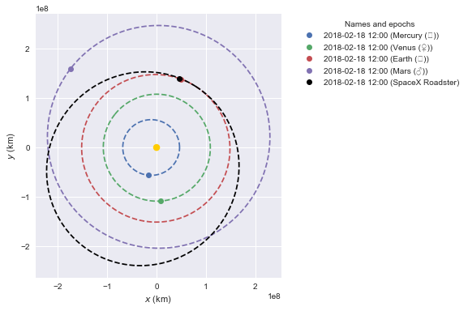

```python
from poliastro.plotting import plot_solar_system

frame = plot_solar_system(outer=False, epoch=EPOCH)
frame.plot(roadster, label="SpaceX Roadster", color='k');
```

```python
from poliastro.plotting import OrbitPlotter3D

from plotly.offline import init_notebook_mode

init_notebook_mode(connected=True)


frame = OrbitPlotter3D()

frame.plot(Orbit.from_body_ephem(Earth, EPOCH), label=Earth)
frame.plot(Orbit.from_body_ephem(Mars, EPOCH), label=Mars)
frame.plot(roadster, label="SpaceX Roadster", color='black')

frame.set_view(30 * u.deg, -100 * u.deg, 2 * u.km)
frame.show()
```

[interactive chart not shown]

# III. Conclusiones y preguntas